# Ch.4 Describnig Data

But taking a look at one graph at a time is so 2010, lets plot multiple graphs together!

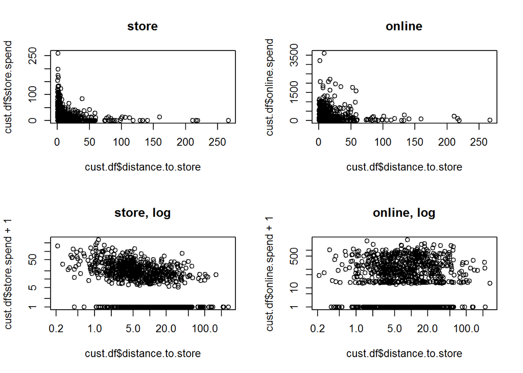

```r
 par(mfrow=c(2, 2))
 plot(cust.df$distance.to.store, cust.df$store.spend, main="store")
 plot(cust.df$distance.to.store, cust.df$online.spend, main="online")
 plot(cust.df$distance.to.store, cust.df$store.spend+1, log="xy",
 main="store, log")
 plot(cust.df$distance.to.store, cust.df$online.spend+1, log="xy",
 main="online, log")
```

```r
  par(mfrow=c(1,1))
```

Okay, lets really blow your mind. Let’s produce several ‘scatter’ plots of charts with easy comands

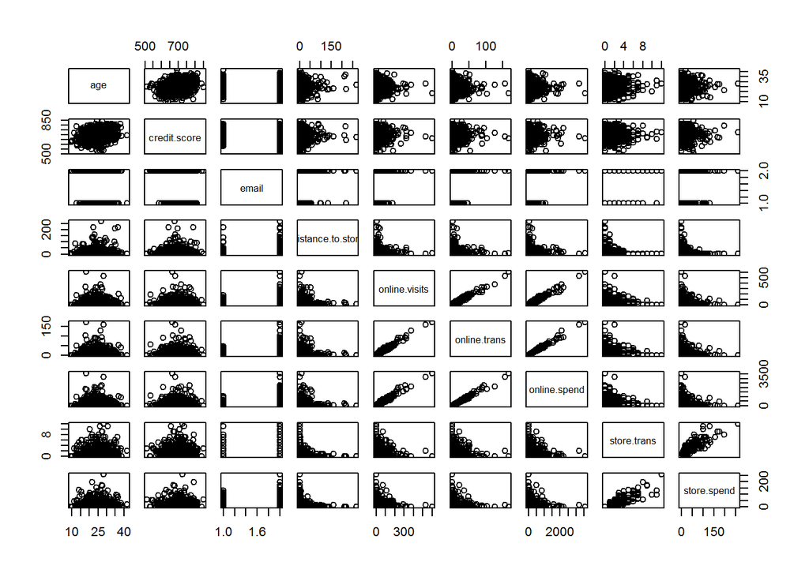

```r
pairs(cust.df[,c(2:10)])


library(car) # install if needed
```

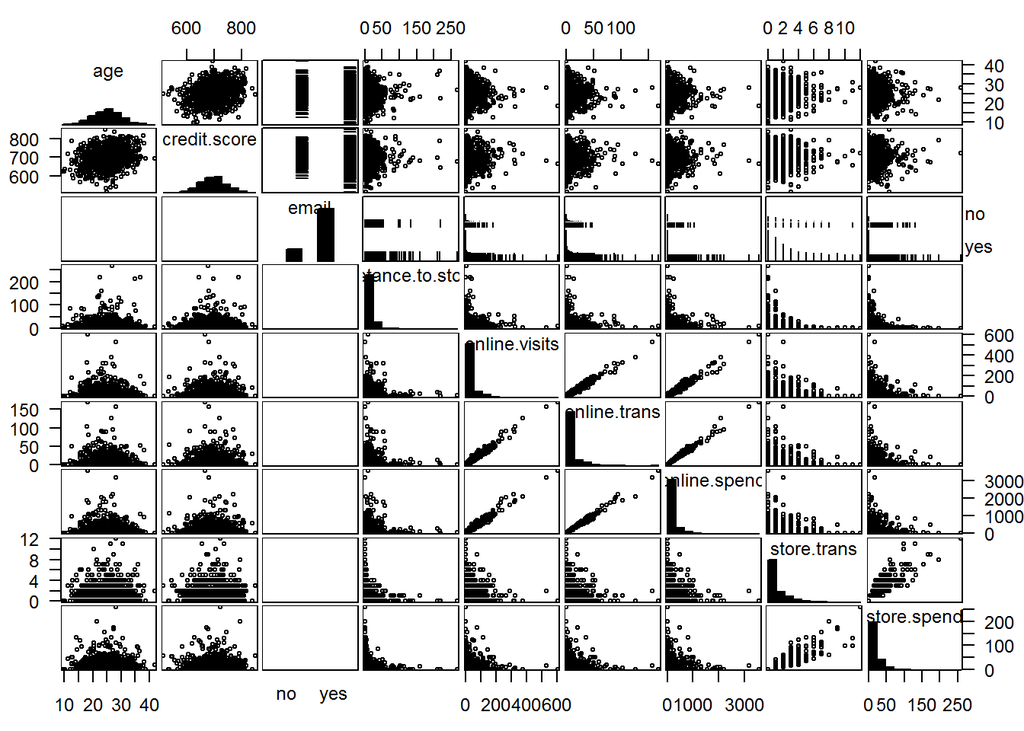

```r
# scatterplotMatrix(formula = ??? age + credit.score + email +
#                                                           distance.to.store + online.visits + online.trans +
#                                                           online.spend + store.trans + store.spend,
#                                                           data=cust.df, diagonal="histogram")

#install.packages("gpairs")
library(gpairs)
gpairs(cust.df[,c(2:10)])
```

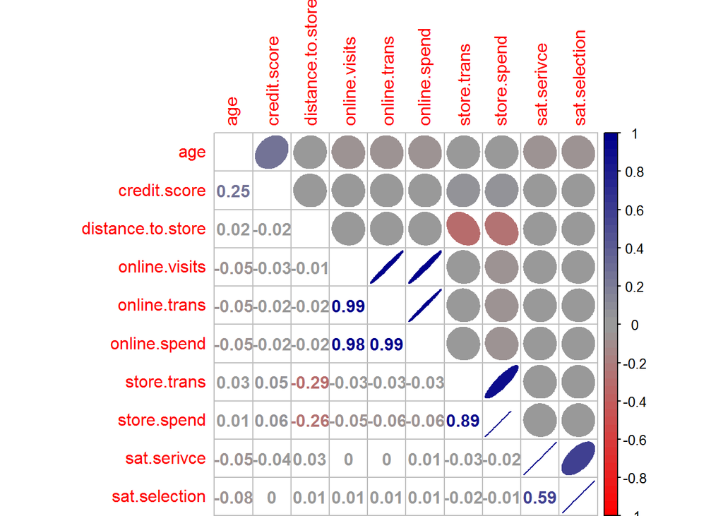

```r
library(corrplot)
library(gplots)
corrplot.mixed(corr=cor(cust.df[,c(2,3,5:12)],
                                                use = "complete.obs"),
                             upper = "ellipse",
                             tl.pos = "lt",
                             col = colorpanel(50, "red","gray60","blue4"))
```

okay, we all know about cor, cor.test (to test if a given correlation is strong)

but these are only measuring linear combinations, and most linear regression are under the assumption that the variables ar egaussian, so we have the typical transofmrations

but let’s talk about the box-cox transformation, we can easily detmirne what it needs to be using the powerTransform() from the car package to find lambda, and then providing the transofmration via bcPower()

```r
library(car)

powerTransform(cust.df$distance.to.store)
```

```
## Estimated transformation parameters
## cust.df$distance.to.store
##              -0.003696395
```

```r
lambda = coef(powerTransform(1/cust.df$distance.to.store))
head(bcPower(cust.df$distance.to.store, lambda = lambda))
```

```
## [1] 0.9504213 3.9027435 0.2514297 1.6640853 3.2399090 2.9314857
```

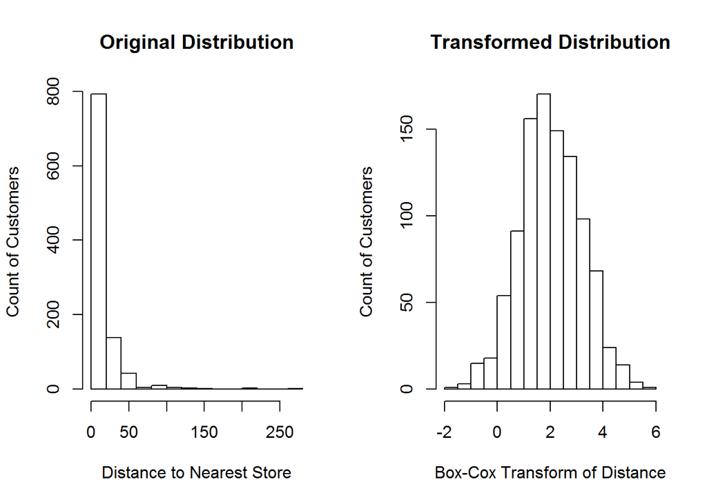

```r
####lets take a look at a transformed and non transformed side by side

par(mfrow=c(1,2))
hist(cust.df$distance.to.store,
     xlab="Distance to Nearest Store", ylab="Count of Customers",
     main="Original Distribution")
hist(bcPower(cust.df$distance.to.store, lambda = lambda),
     xlab="Box-Cox Transform of Distance", ylab="Count of Customers",
     main="Transformed Distribution")
```

```r
par(mfrow = c(1,1))
```

okay, dats nice, but….what about ordinal data, how do we get correlations of them, the psych packages got you covered. it assumes that in ordinal data, the ‘latent’ data (for example, what value people really had in mind) is continious, but they forced it into discret buckets.

```r
library(psych)
resp = !is.na(cust.df$sat.serivce)

polychoric(cbind(cust.df[resp,]$sat.serivce,
                                 cust.df[resp,]$sat.selection)
                     )
```

```
## Call: polychoric(x = cbind(cust.df[resp, ]$sat.serivce, cust.df[resp,
##     ]$sat.selection))
## Polychoric correlations
##    C1   C2
## R1 1.00
## R2 0.67 1.00
##
##  with tau of
##          1     2    3   4
## [1,] -1.89 -0.75 0.54 1.7
## [2,] -0.99  0.11 1.23 2.4
```